# STAT480 Project Title: College tuition, diversity, and pay

Vahid Azizi, Seyedzahra Khoshmanesh, and Saba Moeinizade

4/21/2020

**Abstract:** Many people are interested to know about the tuition, costs, diversity and potential salary when searching for college. In this project, we want to analyze tuition costs across different states, and explore diversity in different schools. The data set includes different variables such as school name, state, type of school, in-state/out-of-state tuition, group/racial/gender category, early/mid-career pay, stem percent and historical tuition information. We are also interested in trends of tuition over time. We will use different summary statistics and visualizations in R to address these problems.

## Getting familaiar with data

```r
address<-c('https://raw.githubusercontent.com/rfordatascience/tidytuesday/master/data/2020/2020-03-10/')

tuition_cost <- readr::read_csv(paste(address,'tuition_cost.csv',sep=""))

tuition_income <- readr::read_csv(paste(address,'tuition_income.csv',sep=""))

salary_potential <- readr::read_csv(paste(address,'salary_potential.csv',sep=""))

historical_tuition <- readr::read_csv(paste(address,'historical_tuition.csv',sep=""))

diversity_school <- readr::read_csv(paste(address,'diversity_school.csv',sep=""))
```

```r
tuition_cost%>%glimpse()
```

```
## Rows: 2,973
## Columns: 10
## $ name                 <chr> "Aaniiih Nakoda College", "Abilene Christian U...
## $ state                <chr> "Montana", "Texas", "Georgia", "Minnesota", "C...
## $ state_code           <chr> "MT", "TX", "GA", "MN", "CA", "CO", "NY", "NY"...
## $ type                 <chr> "Public", "Private", "Public", "For Profit", "...
## $ degree_length        <chr> "2 Year", "4 Year", "2 Year", "2 Year", "4 Yea...
## $ room_and_board       <dbl> NA, 10350, 8474, NA, 16648, 8782, 16030, 11660...
## $ in_state_tuition     <dbl> 2380, 34850, 4128, 17661, 27810, 9440, 38660, ...
## $ in_state_total       <dbl> 2380, 45200, 12602, 17661, 44458, 18222, 54690...
## $ out_of_state_tuition <dbl> 2380, 34850, 12550, 17661, 27810, 20456, 38660...
## $ out_of_state_total   <dbl> 2380, 45200, 21024, 17661, 44458, 29238, 54690...
```

```r
tuition_income%>%glimpse()
```

```
## Rows: 209,012
## Columns: 7
## $ name        <chr> "Piedmont International University", "Piedmont Internat...
## $ state       <chr> "NC", "NC", "NC", "NC", "NC", "NC", "NC", "NC", "NC", "...
## $ total_price <dbl> 20174, 20174, 20174, 20174, 20514, 20514, 20514, 20514,...
## $ year        <dbl> 2016, 2016, 2016, 2016, 2017, 2017, 2017, 2017, 2017, 2...
## $ campus      <chr> "On Campus", "On Campus", "On Campus", "On Campus", "On...
## $ net_cost    <dbl> 11475.00, 11451.00, 16229.00, 15592.00, 11668.39, 11643...
## $ income_lvl  <chr> "0 to 30,000", "30,001 to 48,000", "48_001 to 75,000", ...
```

```r
salary_potential%>%glimpse()
```

```
## Rows: 935
## Columns: 7
## $ rank                      <dbl> 1, 2, 3, 4, 5, 6, 7, 8, 9, 10, 11, 12, 13...
## $ name                      <chr> "Auburn University", "University of Alaba...
## $ state_name                <chr> "Alabama", "Alabama", "Alabama", "Alabama...
## $ early_career_pay          <dbl> 54400, 57500, 52300, 54500, 48400, 46600,...
## $ mid_career_pay            <dbl> 104500, 103900, 97400, 93500, 90500, 8910...
## $ make_world_better_percent <dbl> 51, 59, 50, 61, 52, 53, 48, 57, 56, 58, 6...
## $ stem_percent              <dbl> 31, 45, 15, 30, 3, 12, 27, 17, 17, 20, 8,...
```

```r
historical_tuition%>%glimpse()
```

```
## Rows: 270
## Columns: 4
## $ type         <chr> "All Institutions", "All Institutions", "All Instituti...
## $ year         <chr> "1985-86", "1985-86", "1985-86", "1985-86", "1985-86",...
## $ tuition_type <chr> "All Constant", "4 Year Constant", "2 Year Constant", ...
## $ tuition_cost <dbl> 10893, 12274, 7508, 4885, 5504, 3367, 13822, 16224, 74...
```

```r
diversity_school%>%glimpse()
```

```
## Rows: 50,655
## Columns: 5
## $ name             <chr> "University of Phoenix-Arizona", "University of Ph...
## $ total_enrollment <dbl> 195059, 195059, 195059, 195059, 195059, 195059, 19...
## $ state            <chr> "Arizona", "Arizona", "Arizona", "Arizona", "Arizo...
## $ category         <chr> "Women", "American Indian / Alaska Native", "Asian...
## $ enrollment       <dbl> 134722, 876, 1959, 31455, 13984, 1019, 58209, 1903...
```

## The relationship between college tuition and campus diversity

First, we look at the availabe diverse categories captured in schools across the US.

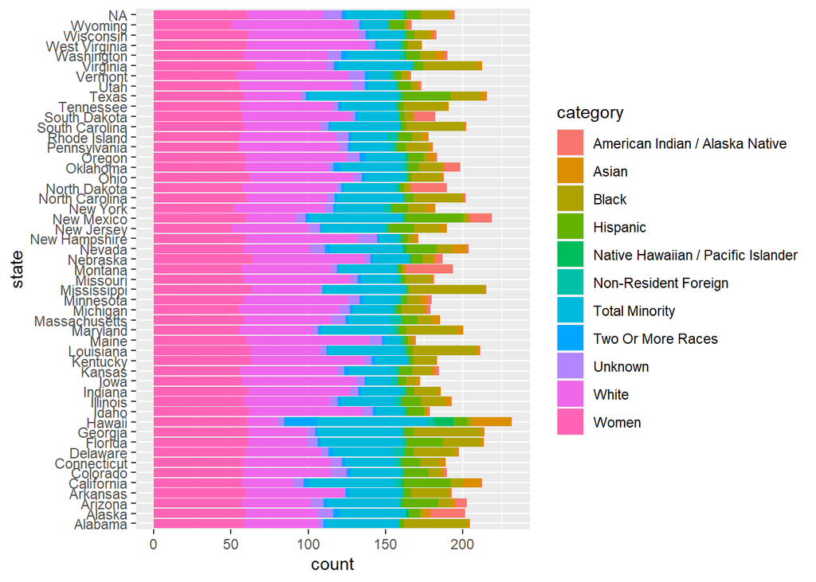

```r
diversity_school %>%
  group_by(state,category) %>%
  mutate(enrollment_rate=round((enrollment/total_enrollment),2)*100) %>%
  summarise(mean_enrollment_rate_per_state=mean(enrollment_rate)) %>%
  arrange(desc(mean_enrollment_rate_per_state)) %>%
    ggplot(aes(x=state,weight=mean_enrollment_rate_per_state,fill=category)) +
  geom_bar()+
  coord_flip()
```

Let us create a new variable which indicates the enrollment rate per each category for each state in the US.

```r
diversity_enroll_rate <- diversity_school %>%
  group_by(state,category) %>%
  mutate(enrollment_rate=round((enrollment/total_enrollment),2)*100) %>%
  summarise(mean_enrollment_rate_per_state=mean(enrollment_rate))

diversity_enroll_rate %>% glimpse()
```

```
## Rows: 561
## Columns: 3
## Groups: state [51]
## $ state                          <chr> "Alabama", "Alabama", "Alabama", "Al...
## $ category                       <chr> "American Indian / Alaska Native", "...
## $ mean_enrollment_rate_per_state <dbl> 0.67123288, 1.26027397, 40.97260274,...
```

Now, let us explore any relationship between the enrollment rate and tuition for each diverse category. We merge tuition_cost dataset with diversity dataset.

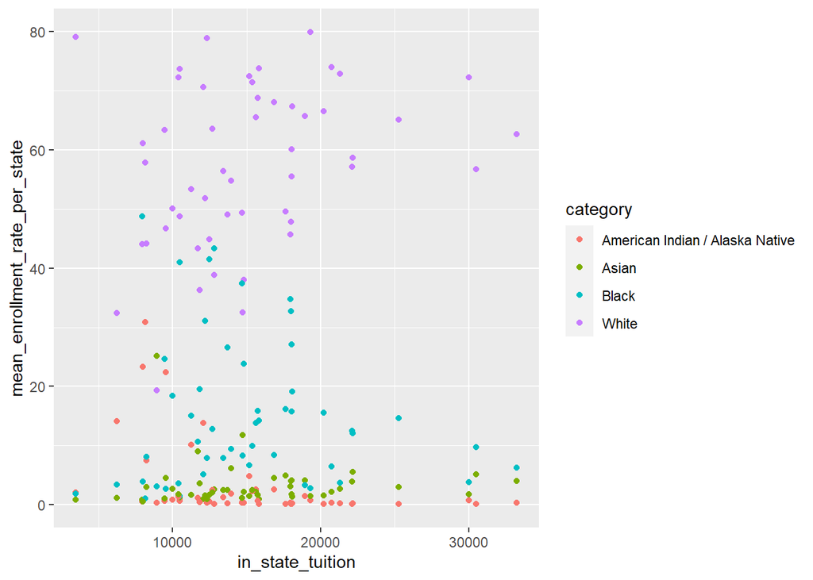

```r
tuition_cost %>%
  group_by(state) %>%
  summarise(in_state_tuition=mean(in_state_tuition),
            out_of_state_tuition=mean(out_of_state_tuition)) %>%
   merge(diversity_enroll_rate) %>%
   filter(category %in% c("Asian","White","Black","American Indian / Alaska Native")) %>%
  ggplot(aes(x=in_state_tuition,y=mean_enrollment_rate_per_state, color=category)) +
  geom_point()
```

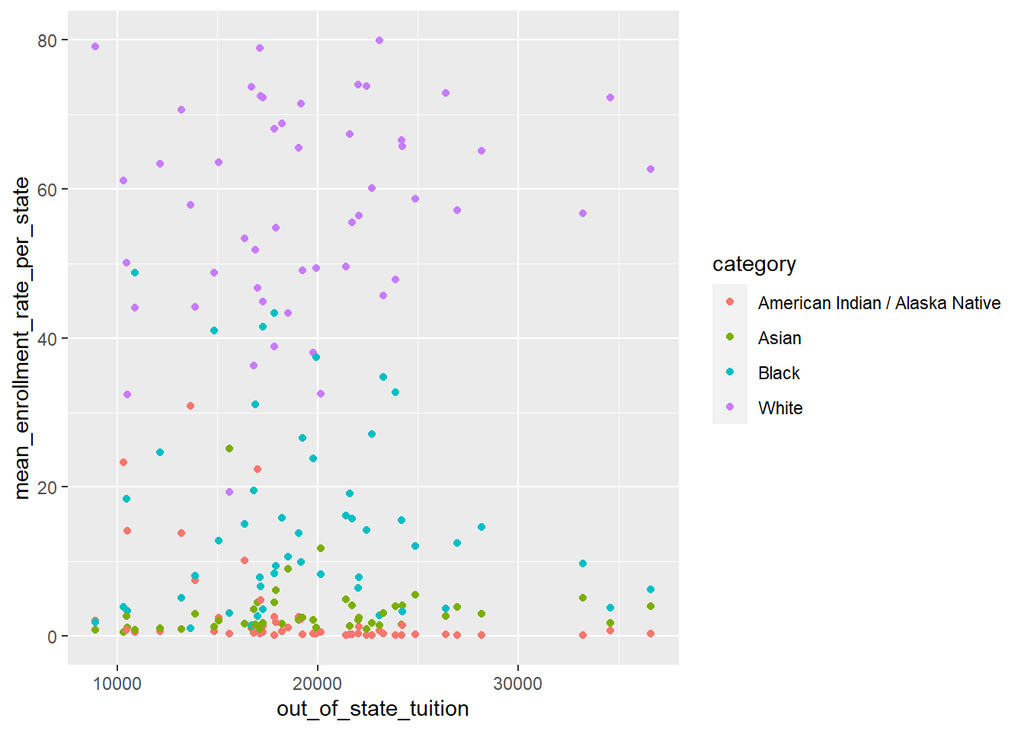

```r
tuition_cost %>%
  group_by(state) %>%
  summarise(in_state_tuition=mean(in_state_tuition),
            out_of_state_tuition=mean(out_of_state_tuition)) %>%
   merge(diversity_enroll_rate) %>%
   filter(category %in% c("Asian","White","Black","American Indian / Alaska Native")) %>%
  ggplot(aes(x=out_of_state_tuition,y=mean_enrollment_rate_per_state, color=category)) +
  geom_point()
```

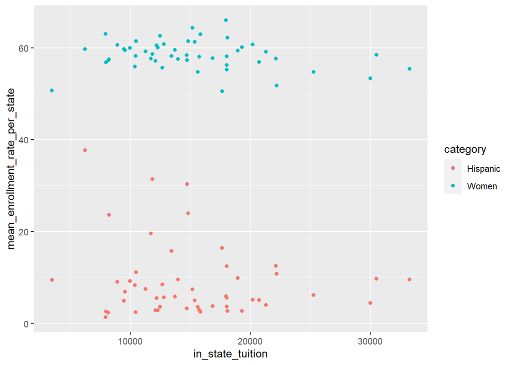

```r
tuition_cost %>%
  group_by(state) %>%
  summarise(in_state_tuition=mean(in_state_tuition),
            out_of_state_tuition=mean(out_of_state_tuition)) %>%
   merge(diversity_enroll_rate) %>%
   filter(category %in% c("Women","Hispanic")) %>%
  ggplot(aes(x=in_state_tuition,y=mean_enrollment_rate_per_state, color=category)) +
  geom_point()
```

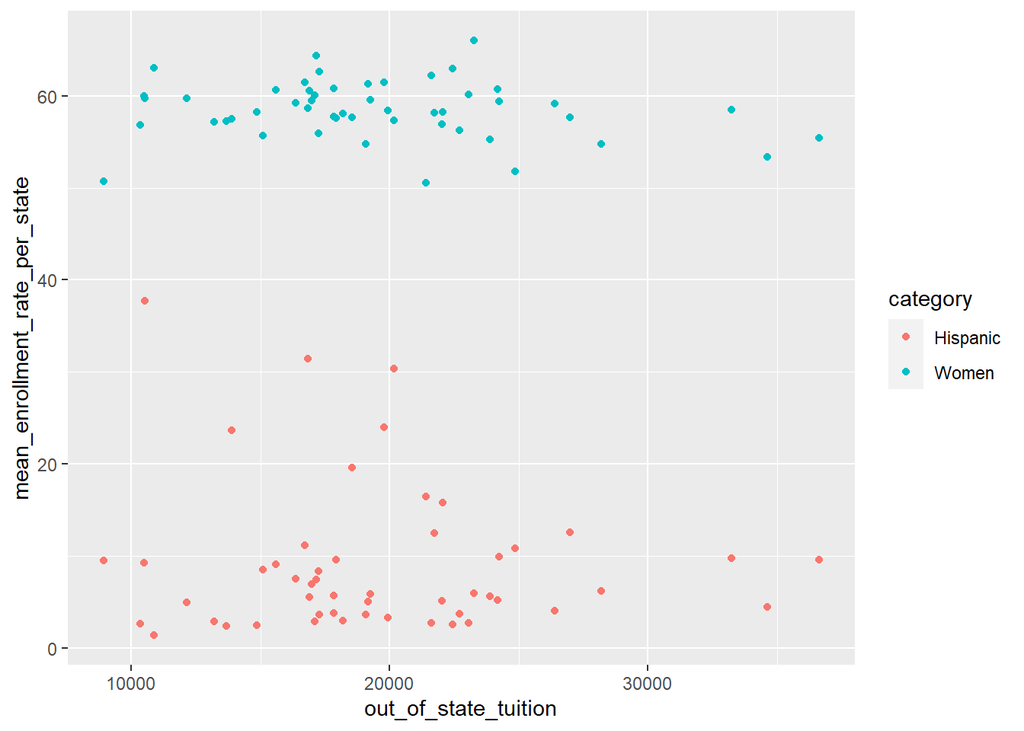

```r
tuition_cost %>%
  group_by(state) %>%
  summarise(in_state_tuition=mean(in_state_tuition),
            out_of_state_tuition=mean(out_of_state_tuition)) %>%
   merge(diversity_enroll_rate) %>%
   filter(category %in% c("Women","Hispanic")) %>%
  ggplot(aes(x=out_of_state_tuition,y=mean_enrollment_rate_per_state, color=category)) +
  geom_point()
```

## The historical trend of tuition

```r
historical_tuition%>%distinct(year)%>%arrange()
```

| year |
| --- |
| 1985-86 |
| 1995-96 |
| 2000-01 |
| 2001-02 |
| 2002-03 |
| 2003-04 |
| 2004-05 |
| 2005-06 |
| 2006-07 |
| 2007-08 |

[output cut: 9 more lines]

```r
historical_tuition%>%distinct(type)
```

| type |
| --- |
| All Institutions |
| Public |
| Private |

```r
historical_tuition%>%distinct(tuition_type)
```

| tuition_type |
| --- |
| All Constant |
| 4 Year Constant |
| 2 Year Constant |
| All Current |
| 4 Year Current |
| 2 Year Current |

```r
table(historical_tuition$type)
```

```
##
## All Institutions          Private           Public
##              114               78               78
```

```r
table(historical_tuition$tuition_type)
```

```
##
## 2 Year Constant  2 Year Current 4 Year Constant  4 Year Current    All Constant
##              45              45              45              45              45
##     All Current
##              45
```

The historical tuition is provided across three types of All Institutions, Public, and Private universities. We observe that the data is available consistantly from 2000 till 2017. For convinience, we will manupliate this column to have the starting year only (e.g., 2000-01 will be 2000).

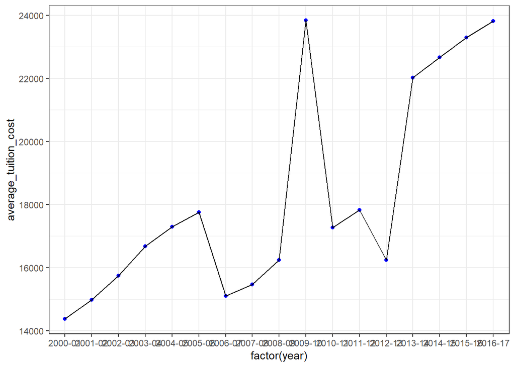

```r
historical_tuition%>%filter(year>=2000)%>%group_by(year)%>%summarise(average_tuition_cost=mean(tuition_cost))%>%
 ggplot(aes(x=factor(year),y=average_tuition_cost,group=1))+geom_point(color='blue')+geom_line()+theme_bw()
```

The average tuition is increased from 2000 till 2005, then there is a sudden decrease and after that we see a huge jump from 2008 to 2009. This follows by a sudden drop and then again increases in 2012.

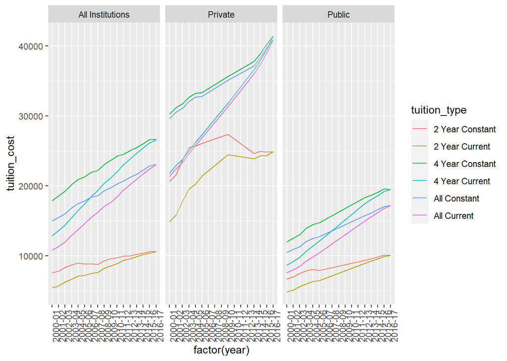

```r
historical_tuition%>%filter(year>=2000)%>%
 ggplot(aes(x=factor(year),y=tuition_cost,group=tuition_type,color=tuition_type))+geom_line()+facet_wrap(~type)+
  theme(axis.text.x = element_text(angle = 90,hjust=1))
```

## Cost of college tuition in US by geographic area

```r
head(tuition_cost)
```

| name | state | state_code | type | degree_length | room_and_board | in_state_tuition | in_state_total | out_of_state_tuition | out_of_state_total |
| --- | --- | --- | --- | --- | --- | --- | --- | --- | --- |
| Aaniiih Nakoda College | Montana | MT | Public | 2 Year | NA | 2380 | 2380 | 2380 | 2380 |
| Abilene Christian University | Texas | TX | Private | 4 Year | 10350 | 34850 | 45200 | 34850 | 45200 |
| Abraham Baldwin Agricultural College | Georgia | GA | Public | 2 Year | 8474 | 4128 | 12602 | 12550 | 21024 |
| Academy College | Minnesota | MN | For Profit | 2 Year | NA | 17661 | 17661 | 17661 | 17661 |
| Academy of Art University | California | CA | For Profit | 4 Year | 16648 | 27810 | 44458 | 27810 | 44458 |
| Adams State University | Colorado | CO | Public | 4 Year | 8782 | 9440 | 18222 | 20456 | 29238 |

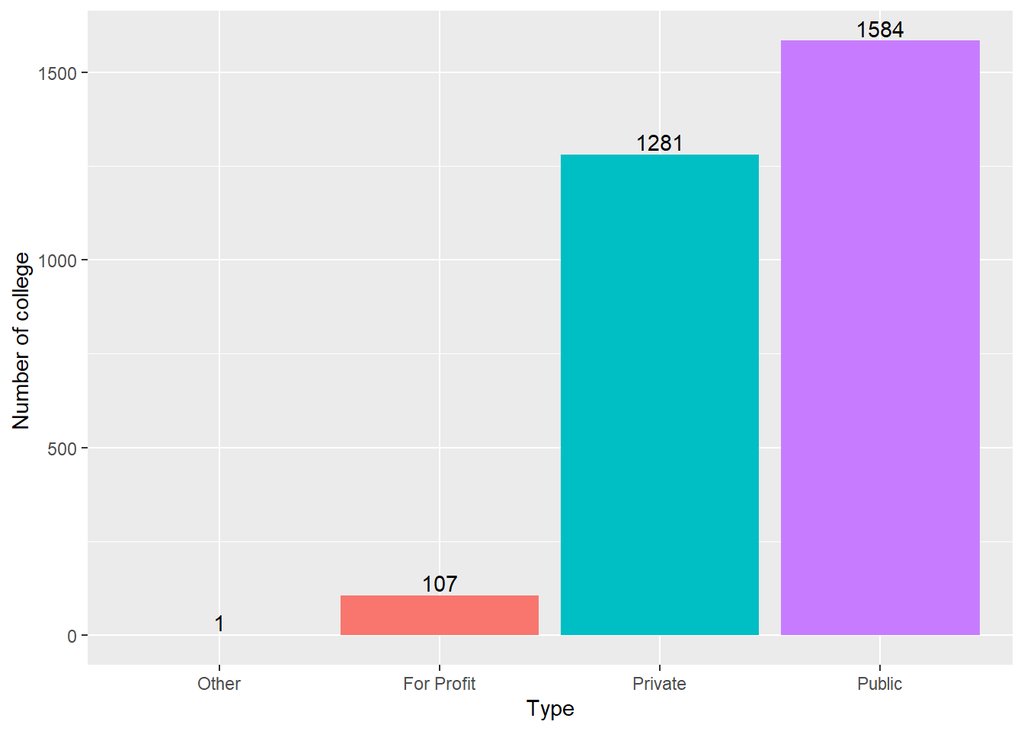

```r
library(forcats)

tuition_cost %>% group_by(type) %>% summarise(n=n()) %>% ggplot(aes(x=fct_reorder(type,n), y=n,fill=as.factor(type)))+ geom_bar(stat="identity") +labs(y="Number of college ",x="Type")+
  geom_text(aes(label=n), position=position_dodge(width=0.9), vjust=-0.25)+
  theme(legend.position = "none")
```

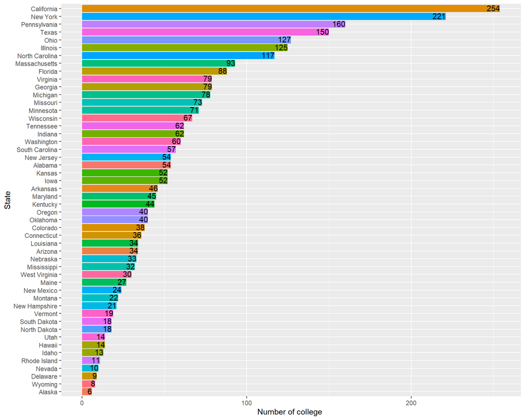

```r
tuition_cost[!is.na(tuition_cost$state),] %>% group_by(state) %>% summarise(n=n()) %>% ggplot(aes(x=fct_reorder(state,n), y=n,fill=as.factor(state)))+ geom_bar(position = 'dodge',stat="identity") +labs(y="Number of college ",x="State")+
  geom_text(aes(label=n), position=position_dodge(width=.3),hjust=1, vjust=.4)+
  coord_flip()+
  theme(legend.position = "none")
```

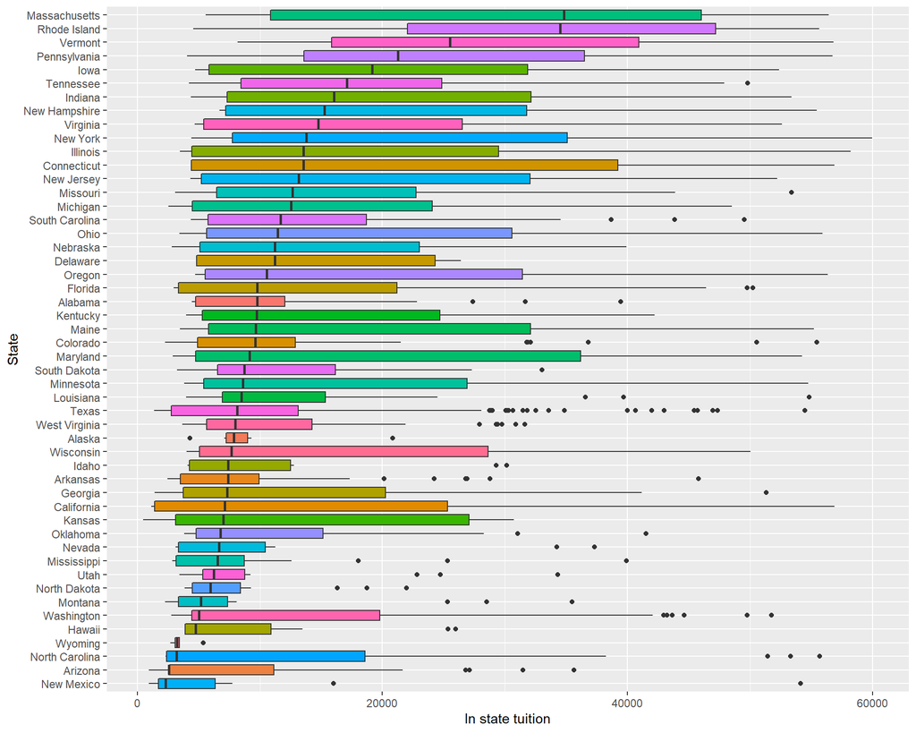

```r
tuition_cost[!is.na(tuition_cost$state),] %>% group_by(state) %>% ggplot(aes(x=fct_reorder(state,in_state_tuition), y=in_state_tuition,fill=as.factor(state))) +
  geom_boxplot()+
  coord_flip() +
  labs(x="State",y="In state tuition")+
  theme(legend.position = "none")
```

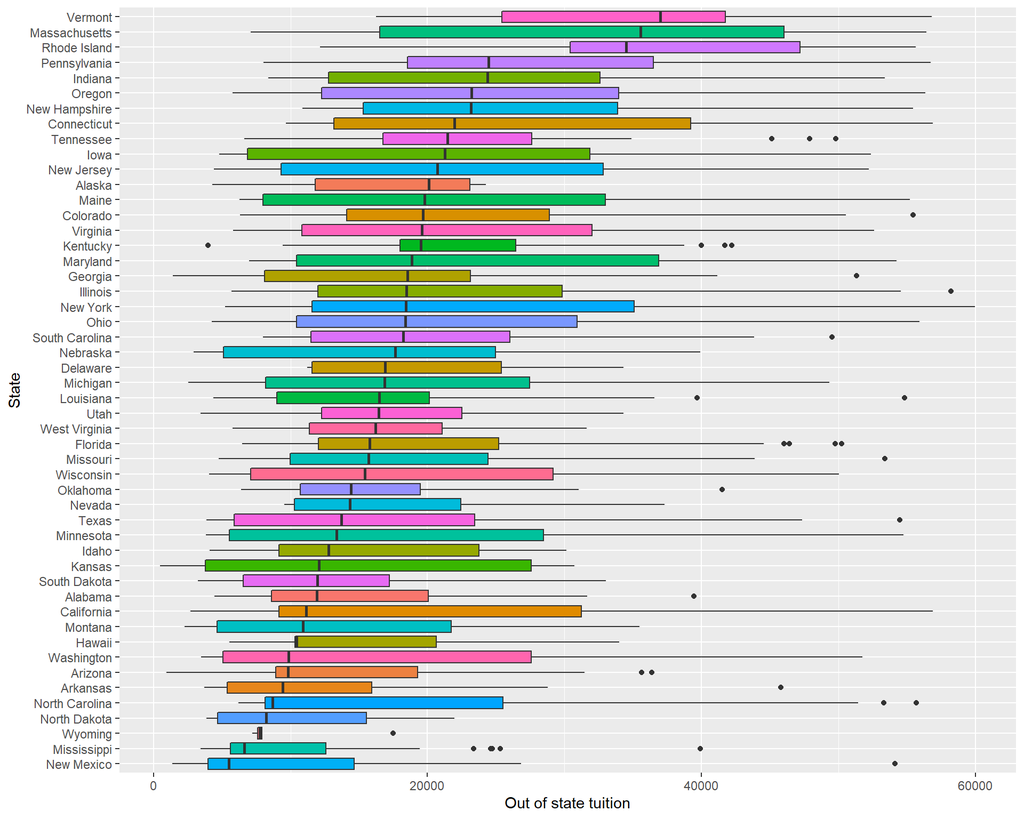

```r
tuition_cost[!is.na(tuition_cost$state),] %>% group_by(state) %>% ggplot(aes(x=fct_reorder(state,out_of_state_tuition), y=out_of_state_tuition,fill=as.factor(state))) +
  geom_boxplot()+
  coord_flip() +
  labs(x="State",y="Out of state tuition")+
  theme(legend.position = "none")
```

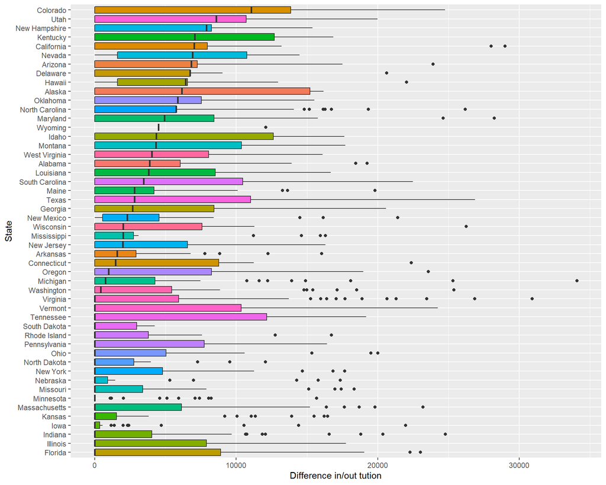

```r
tuition_cost[!is.na(tuition_cost$state),] %>% mutate(tuition_diff_in_out=out_of_state_tuition-in_state_tuition) %>% group_by(state) %>% ggplot(aes(x=fct_reorder(state,tuition_diff_in_out), y=tuition_diff_in_out,fill=as.factor(state))) +
  geom_boxplot()+
  coord_flip() +
  labs(x="State",y="Difference in/out tution")+
  theme(legend.position = "none")
```

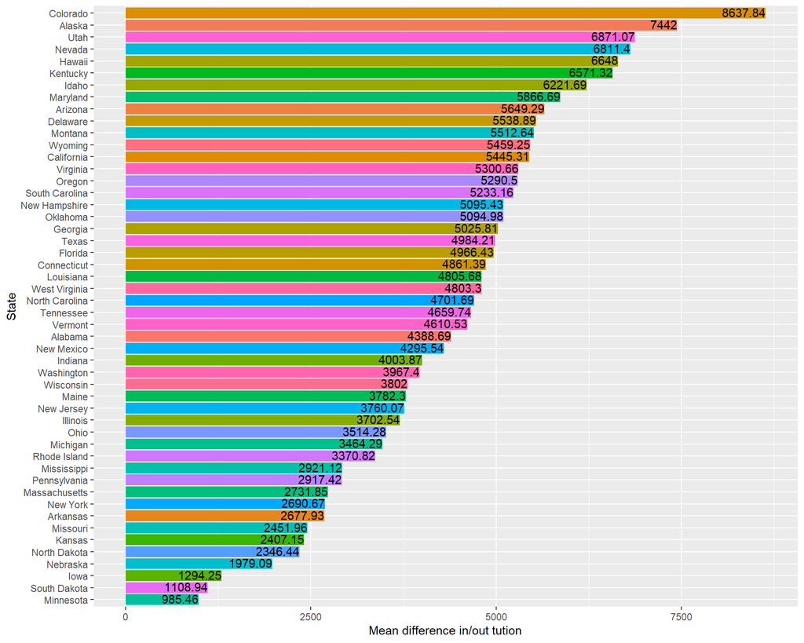

```r
tuition_cost[!is.na(tuition_cost$state),] %>% mutate(tuition_diff_in_out=out_of_state_tuition-in_state_tuition) %>% group_by(state) %>%
  summarise(mean_diff=round(mean(tuition_diff_in_out),2)) %>%
  ggplot(aes(x=fct_reorder(state,mean_diff), y=mean_diff,fill=as.factor(state))) +
  geom_bar(stat="identity")+
  geom_text(aes(label=mean_diff), position=position_dodge(width=.3),hjust=1, vjust=.4)+
  coord_flip() +
  labs(x="State",y="Mean difference in/out tution")+
  theme(legend.position = "none")
```

## Average potential salary in early/mid-career

```r
salary_potential%>%distinct(state_name)%>%count()
```

| n |
| --- |
| 50 |

This data includes early/mid career pay across 50 states. Let’s take a look at universities in Iowa and compare their potential slary.

```r
salary_potential%>%filter(state_name=="Iowa")%>%arrange(name)
```

| rank | name | state_name | early_career_pay | mid_career_pay | make_world_better_percent | stem_percent |
| --- | --- | --- | --- | --- | --- | --- |
| 5 | Allen College | Iowa | 51600 | 91300 | NA | 0 |
| 9 | Central College | Iowa | 49000 | 88800 | 55 | 36 |
| 20 | Clarke University | Iowa | 44900 | 80200 | 52 | 6 |
| 13 | Coe College | Iowa | 47200 | 86900 | 41 | 24 |
| 6 | Cornell College | Iowa | 49600 | 90600 | 47 | 22 |
| 8 | Dordt College | Iowa | 51000 | 89600 | 57 | 17 |
| 2 | Drake University | Iowa | 52800 | 99900 | 49 | 7 |
| 10 | Graceland University-Lamoni | Iowa | 48300 | 88700 | 66 | 5 |
| 4 | Grinnell College | Iowa | 53400 | 96500 | 49 | 41 |
| 1 | Iowa State University | Iowa | 56100 | 101300 | 48 | 31 |

[output cut: 15 more lines]

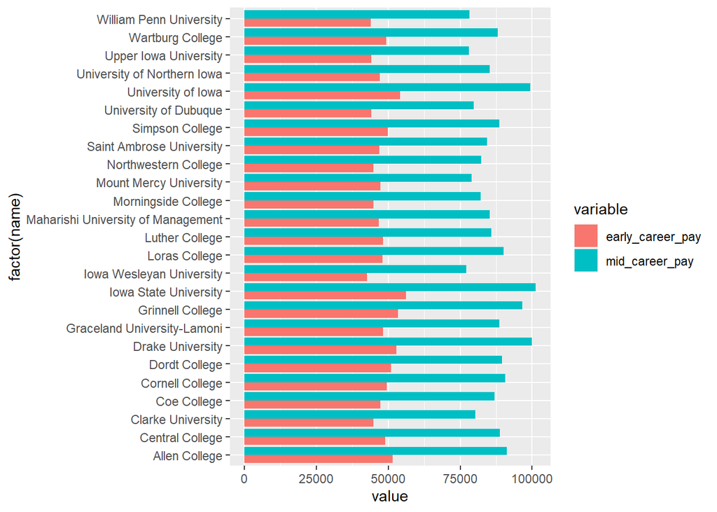

```r
salary_potential%>%filter(state_name=="Iowa")%>%select(name,early_career_pay,mid_career_pay)%>%reshape2::melt()%>%ggplot()+
  geom_bar(aes(x=factor(name),y=value,fill=variable),stat='identity',position = 'dodge')+coord_flip()
```